# Pneumonia Detection (Capstone Project AIML)

# Stage 4: Data Preprocessing

```python
!pip install opencv-python
```

## Preprocessing Function: Convert to Grayscale + Normalize

```python
import cv2
import numpy as np

def preprocess_image(image, target_size=(224, 224)):
    """
    Converts image to grayscale,
    resizes, normalizes, and adds channel dimension.
    """
    # Convert to float
    image = image.astype(np.float32)

    # Resize to reduce memory usage
    image = cv2.resize(image, target_size)

    # Normalize pixel values to [0, 1]
    image = image / 255.0

    # Add channel dimension for CNN
    image = np.expand_dims(image, axis=-1)

    return image
```

## Visualize Image Before & After Preprocessing

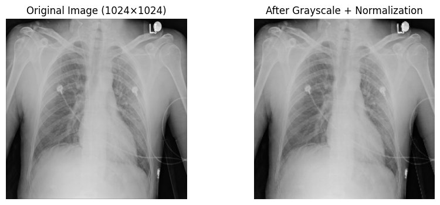

```python
# Select a random image
sample_id = train_labels.sample(1)['patientId'].values[0]

original_image = load_dicom_image(sample_id)
processed_image = preprocess_image(original_image)

plt.figure(figsize=(10,4))

# Original image
plt.subplot(1,2,1)
plt.imshow(original_image, cmap='gray')
plt.title("Original Image (1024×1024)")
plt.axis('off')

# Preprocessed image
plt.subplot(1,2,2)
plt.imshow(processed_image.squeeze(), cmap='gray')
plt.title("After Grayscale + Normalization")
plt.axis('off')

plt.show()
```

## Apply Preprocessing and Create Subset

```python
# Use a subset to avoid memory issues
SAMPLE_SIZE = 3000
subset_df = train_labels.sample(SAMPLE_SIZE, random_state=42)

X = []
y = []

for _, row in subset_df.iterrows():
    img = load_dicom_image(row['patientId'])
    img = preprocess_image(img)
    X.append(img)
    y.append(row['Target'])

X = np.array(X)
y = np.array(y)

print("X shape:", X.shape)
print("y shape:", y.shape)
```

```
X shape: (3000, 224, 224, 1)
y shape: (3000,)
```

## Split Data into Train, Validation, and Test Sets

```python
from sklearn.model_selection import train_test_split

# 70% Train, 15% Validation, 15% Test
X_train, X_temp, y_train, y_temp = train_test_split(
    X, y, test_size=0.3, random_state=42, stratify=y
)

X_val, X_test, y_val, y_test = train_test_split(
    X_temp, y_temp, test_size=0.5, random_state=42, stratify=y_temp
)

print("Training set:", X_train.shape)
print("Validation set:", X_val.shape)
print("Test set:", X_test.shape)
```

```
Training set: (2100, 224, 224, 1)
Validation set: (450, 224, 224, 1)
Test set: (450, 224, 224, 1)
```

# Stage 5: Model Building

## Define CNN Model (From Scratch)

```python
# CNN model

model = Sequential([
    Conv2D(32, (3,3), activation='relu', input_shape=X_train.shape[1:]),
    MaxPooling2D(2,2),

    Conv2D(64, (3,3), activation='relu'),
    MaxPooling2D(2,2),

    Conv2D(128, (3,3), activation='relu'),
    MaxPooling2D(2,2),

    Flatten(),
    Dense(128, activation='relu'),
    Dropout(0.5),
    Dense(1, activation='sigmoid')  # Binary classification
])
```

## Compile the Model

```python
model.compile(
    optimizer=Adam(learning_rate=0.001),
    loss='binary_crossentropy',
    metrics=['accuracy']
)

model.summary()
```

```
Model: "sequential"
```

```
┏━━━━━━━━━━━━━━━━━━━━━━━━━━━━━━━━━┳━━━━━━━━━━━━━━━━━━━━━━━━┳━━━━━━━━━━━━━━━┓
┃ Layer (type)                    ┃ Output Shape           ┃       Param # ┃
┡━━━━━━━━━━━━━━━━━━━━━━━━━━━━━━━━━╇━━━━━━━━━━━━━━━━━━━━━━━━╇━━━━━━━━━━━━━━━┩
│ conv2d (Conv2D)                 │ (None, 222, 222, 32)   │           320 │
├─────────────────────────────────┼────────────────────────┼───────────────┤
│ max_pooling2d (MaxPooling2D)    │ (None, 111, 111, 32)   │             0 │
├─────────────────────────────────┼────────────────────────┼───────────────┤
│ conv2d_1 (Conv2D)               │ (None, 109, 109, 64)   │        18,496 │
├─────────────────────────────────┼────────────────────────┼───────────────┤
│ max_pooling2d_1 (MaxPooling2D)  │ (None, 54, 54, 64)     │             0 │
├─────────────────────────────────┼────────────────────────┼───────────────┤
│ conv2d_2 (Conv2D)               │ (None, 52, 52, 128)    │        73,856 │
├─────────────────────────────────┼────────────────────────┼───────────────┤
│ max_pooling2d_2 (MaxPooling2D)  │ (None, 26, 26, 128)    │             0 │
├─────────────────────────────────┼────────────────────────┼───────────────┤
│ flatten (Flatten)               │ (None, 86528)          │             0 │
├─────────────────────────────────┼────────────────────────┼───────────────┤
│ dense (Dense)                   │ (None, 128)            │    11,075,712 │
├─────────────────────────────────┼────────────────────────┼───────────────┤
│ dropout (Dropout)               │ (None, 128)            │             0 │
├─────────────────────────────────┼────────────────────────┼───────────────┤
│ dense_1 (Dense)                 │ (None, 1)              │           129 │
└─────────────────────────────────┴────────────────────────┴───────────────┘
```

```
 Total params: 11,168,513 (42.60 MB)
```

```
 Trainable params: 11,168,513 (42.60 MB)
```

```
 Non-trainable params: 0 (0.00 B)
```

## Train Model

```python
history = model.fit(
    X_train, y_train,
    validation_data=(X_val, y_val),
    epochs=10,
    batch_size=32
)
```

```
66/66 ━━━━━━━━━━━━━━━━━━━━ 17s 145ms/step - accuracy: 0.6937 - loss: 0.5938 - val_accuracy: 0.7511 - val_loss: 0.5009
66/66 ━━━━━━━━━━━━━━━━━━━━ 3s 51ms/step - accuracy: 0.7425 - loss: 0.5100 - val_accuracy: 0.7711 - val_loss: 0.5015
66/66 ━━━━━━━━━━━━━━━━━━━━ 4s 54ms/step - accuracy: 0.7576 - loss: 0.5055 - val_accuracy: 0.7711 - val_loss: 0.4998
66/66 ━━━━━━━━━━━━━━━━━━━━ 3s 51ms/step - accuracy: 0.7744 - loss: 0.4769 - val_accuracy: 0.7556 - val_loss: 0.5147
66/66 ━━━━━━━━━━━━━━━━━━━━ 3s 51ms/step - accuracy: 0.7983 - loss: 0.4462 - val_accuracy: 0.7689 - val_loss: 0.5330
66/66 ━━━━━━━━━━━━━━━━━━━━ 3s 51ms/step - accuracy: 0.7989 - loss: 0.4306 - val_accuracy: 0.7622 - val_loss: 0.5041
66/66 ━━━━━━━━━━━━━━━━━━━━ 4s 54ms/step - accuracy: 0.8176 - loss: 0.4289 - val_accuracy: 0.7489 - val_loss: 0.5723
66/66 ━━━━━━━━━━━━━━━━━━━━ 3s 51ms/step - accuracy: 0.8403 - loss: 0.3765 - val_accuracy: 0.7444 - val_loss: 0.6284
66/66 ━━━━━━━━━━━━━━━━━━━━ 3s 53ms/step - accuracy: 0.8560 - loss: 0.3248 - val_accuracy: 0.7733 - val_loss: 0.6187
66/66 ━━━━━━━━━━━━━━━━━━━━ 4s 54ms/step - accuracy: 0.8626 - loss: 0.3143 - val_accuracy: 0.7733 - val_loss: 0.6485
```

## Evaluate Model on Test Set

```python
test_loss, test_accuracy = model.evaluate(X_test, y_test)
print(f"Test Accuracy: {test_accuracy:.4f}")
```

```
15/15 ━━━━━━━━━━━━━━━━━━━━ 0s 17ms/step - accuracy: 0.7381 - loss: 0.6944
Test Accuracy: 0.7511
```

## Plot Training & Validation Curves

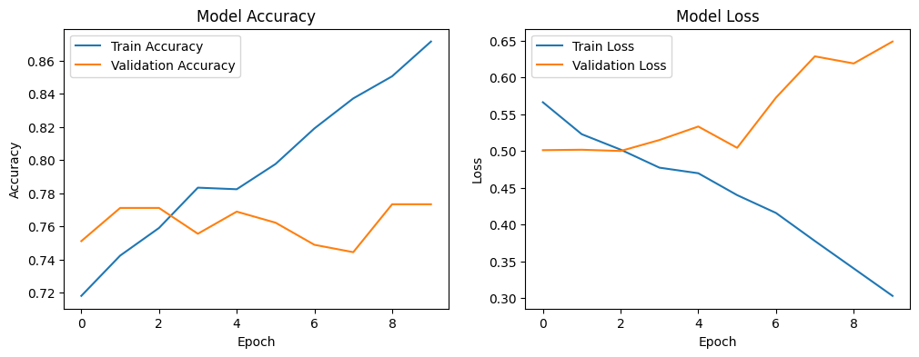

```python
plt.figure(figsize=(12,4))

# Accuracy plot
plt.subplot(1,2,1)
plt.plot(history.history['accuracy'], label='Train Accuracy')
plt.plot(history.history['val_accuracy'], label='Validation Accuracy')
plt.xlabel('Epoch')
plt.ylabel('Accuracy')
plt.title('Model Accuracy')
plt.legend()

# Loss plot
plt.subplot(1,2,2)
plt.plot(history.history['loss'], label='Train Loss')
plt.plot(history.history['val_loss'], label='Validation Loss')
plt.xlabel('Epoch')
plt.ylabel('Loss')
plt.title('Model Loss')
plt.legend()

plt.show()
```

### Model Performance Observations

- The CNN model trained from scratch shows steady learning behavior, with training accuracy increasing from approximately 69% to 86% over 10 epochs.
- Validation accuracy remains relatively stable in the range of 75%–78%, indicating reasonable generalization to unseen data.
- The final test accuracy of 75.11% is closely aligned with the validation performance, suggesting no major data leakage issues.
- Validation loss begins to increase after the early epochs while training loss continues to decrease, indicating clear overfitting as training progresses.
- The model contains approximately 11.2 million trainable parameters, with a large proportion concentrated in the fully connected layers, which increases the risk of overfitting on a limited dataset.
- Overall, this CNN serves as a solid baseline model for pneumonia classification; however, performance can likely be improved through stronger regularization, data augmentation, class balancing, or the use of transfer learning.

# Stage 6: Transfer Learning

## Purpose of Transfer learning:

- Improve pneumonia detection performance by leveraging pre-trained CNN models and compare them against the baseline CNN built from scratch.

## Prepare Data for Transfer Learning

- **Image Preprocessing for Transfer Learning**

```python
import cv2
import numpy as np

def preprocess_image_rgb(image, target_size=(224, 224)):
    """
    Preprocess DICOM image for transfer learning models.
    Steps:
    1. Resize image
    2. Normalize pixel values
    3. Convert grayscale to RGB
    """
    image = image.astype(np.float32)
    image = cv2.resize(image, target_size)
    image = image / 255.0

    # Convert grayscale → RGB
    image = np.stack((image,)*3, axis=-1)

    return image
```

- **Create Dataset for Transfer Learning**

```python
X_tl = []
y_tl = []

for _, row in subset_df.iterrows():
    img = load_dicom_image(row['patientId'])
    img = preprocess_image_rgb(img)
    X_tl.append(img)
    y_tl.append(row['Target'])

X_tl = np.array(X_tl)
y_tl = np.array(y_tl)

print("X shape:", X_tl.shape)
print("y shape:", y_tl.shape)
```

```
X shape: (3000, 224, 224, 3)
y shape: (3000,)
```

- **Train / Validation / Test Split**

```python
from sklearn.model_selection import train_test_split

X_train_tl, X_temp_tl, y_train_tl, y_temp_tl = train_test_split(
    X_tl, y_tl, test_size=0.3, stratify=y_tl, random_state=42
)

X_val_tl, X_test_tl, y_val_tl, y_test_tl = train_test_split(
    X_temp_tl, y_temp_tl, test_size=0.5, stratify=y_temp_tl, random_state=42
)
```

## Transfer Learning Model 1 – ResNet50

### Load Pre-trained ResNet50

```python
from tensorflow.keras.applications import ResNet50
from tensorflow.keras.layers import Dense, Dropout, GlobalAveragePooling2D
from tensorflow.keras.models import Model
from tensorflow.keras.optimizers import Adam
```

```python
base_resnet = ResNet50(
    weights='imagenet',
    include_top=False,
    input_shape=(224, 224, 3)
)

# Freeze base model weights
base_resnet.trainable = False
```

## Create New Architecture (Custom Classification Head)

```python
x = base_resnet.output
x = GlobalAveragePooling2D()(x)
x = Dense(128, activation='relu')(x)
x = Dropout(0.5)(x)
output = Dense(1, activation='sigmoid')(x)

resnet_model = Model(inputs=base_resnet.input, outputs=output)

# Display model architecture
resnet_model.summary()
```

```
Model: "functional_1"
```

```
┏━━━━━━━━━━━━━━━━━━━━━┳━━━━━━━━━━━━━━━━━━━┳━━━━━━━━━━━━┳━━━━━━━━━━━━━━━━━━━┓
┃ Layer (type)        ┃ Output Shape      ┃    Param # ┃ Connected to      ┃
┡━━━━━━━━━━━━━━━━━━━━━╇━━━━━━━━━━━━━━━━━━━╇━━━━━━━━━━━━╇━━━━━━━━━━━━━━━━━━━┩
│ input_layer_2       │ (None, 224, 224,  │          0 │ -                 │
│ (InputLayer)        │ 3)                │            │                   │
├─────────────────────┼───────────────────┼────────────┼───────────────────┤
│ conv1_pad           │ (None, 230, 230,  │          0 │ input_layer_2[0]… │
│ (ZeroPadding2D)     │ 3)                │            │                   │
├─────────────────────┼───────────────────┼────────────┼───────────────────┤
│ conv1_conv (Conv2D) │ (None, 112, 112,  │      9,472 │ conv1_pad[0][0]   │
│                     │ 64)               │            │                   │
├─────────────────────┼───────────────────┼────────────┼───────────────────┤
│ conv1_bn            │ (None, 112, 112,  │        256 │ conv1_conv[0][0]  │
│ (BatchNormalizatio… │ 64)               │            │                   │
├─────────────────────┼───────────────────┼────────────┼───────────────────┤
│ conv1_relu          │ (None, 112, 112,  │          0 │ conv1_bn[0][0]    │
│ (Activation)        │ 64)               │            │                   │
├─────────────────────┼───────────────────┼────────────┼───────────────────┤
│ pool1_pad           │ (None, 114, 114,  │          0 │ conv1_relu[0][0]  │
│ (ZeroPadding2D)     │ 64)               │            │                   │
├─────────────────────┼───────────────────┼────────────┼───────────────────┤
│ pool1_pool          │ (None, 56, 56,    │          0 │ pool1_pad[0][0]   │
│ (MaxPooling2D)      │ 64)               │            │                   │
├─────────────────────┼───────────────────┼────────────┼───────────────────┤
│ conv2_block1_1_conv │ (None, 56, 56,    │      4,160 │ pool1_pool[0][0]  │
│ (Conv2D)            │ 64)               │            │                   │
├─────────────────────┼───────────────────┼────────────┼───────────────────┤
│ conv2_block1_1_bn   │ (None, 56, 56,    │        256 │ conv2_block1_1_c… │
│ (BatchNormalizatio… │ 64)               │            │                   │
├─────────────────────┼───────────────────┼────────────┼───────────────────┤
│ conv2_block1_1_relu │ (None, 56, 56,    │          0 │ conv2_block1_1_b… │
│ (Activation)        │ 64)               │            │                   │
├─────────────────────┼───────────────────┼────────────┼───────────────────┤
│ conv2_block1_2_conv │ (None, 56, 56,    │     36,928 │ conv2_block1_1_r… │
│ (Conv2D)            │ 64)               │            │                   │
├─────────────────────┼───────────────────┼────────────┼───────────────────┤
│ conv2_block1_2_bn   │ (None, 56, 56,    │        256 │ conv2_block1_2_c… │
│ (BatchNormalizatio… │ 64)               │            │                   │
├─────────────────────┼───────────────────┼────────────┼───────────────────┤
│ conv2_block1_2_relu │ (None, 56, 56,    │          0 │ conv2_block1_2_b… │
```

[output cut: 482 more lines]

```
│ conv5_block3_add    │ (None, 7, 7,      │          0 │ conv5_block2_out… │
│ (Add)               │ 2048)             │            │ conv5_block3_3_b… │
├─────────────────────┼───────────────────┼────────────┼───────────────────┤
│ conv5_block3_out    │ (None, 7, 7,      │          0 │ conv5_block3_add… │
│ (Activation)        │ 2048)             │            │                   │
├─────────────────────┼───────────────────┼────────────┼───────────────────┤
│ global_average_poo… │ (None, 2048)      │          0 │ conv5_block3_out… │
│ (GlobalAveragePool… │                   │            │                   │
├─────────────────────┼───────────────────┼────────────┼───────────────────┤
│ dense_2 (Dense)     │ (None, 128)       │    262,272 │ global_average_p… │
├─────────────────────┼───────────────────┼────────────┼───────────────────┤
│ dropout_1 (Dropout) │ (None, 128)       │          0 │ dense_2[0][0]     │
├─────────────────────┼───────────────────┼────────────┼───────────────────┤
│ dense_3 (Dense)     │ (None, 1)         │        129 │ dropout_1[0][0]   │
└─────────────────────┴───────────────────┴────────────┴───────────────────┘
```

```
 Total params: 23,850,113 (90.98 MB)
```

```
 Trainable params: 262,401 (1.00 MB)
```

```
 Non-trainable params: 23,587,712 (89.98 MB)
```

### Compile & Train ResNet50 Model

```python
resnet_model.compile(
    optimizer=Adam(learning_rate=0.0001),
    loss='binary_crossentropy',
    metrics=['accuracy']
)

model.summary()
```

```
Model: "sequential"
```

```
┏━━━━━━━━━━━━━━━━━━━━━━━━━━━━━━━━━┳━━━━━━━━━━━━━━━━━━━━━━━━┳━━━━━━━━━━━━━━━┓
┃ Layer (type)                    ┃ Output Shape           ┃       Param # ┃
┡━━━━━━━━━━━━━━━━━━━━━━━━━━━━━━━━━╇━━━━━━━━━━━━━━━━━━━━━━━━╇━━━━━━━━━━━━━━━┩
│ conv2d (Conv2D)                 │ (None, 222, 222, 32)   │           320 │
├─────────────────────────────────┼────────────────────────┼───────────────┤
│ max_pooling2d (MaxPooling2D)    │ (None, 111, 111, 32)   │             0 │
├─────────────────────────────────┼────────────────────────┼───────────────┤
│ conv2d_1 (Conv2D)               │ (None, 109, 109, 64)   │        18,496 │
├─────────────────────────────────┼────────────────────────┼───────────────┤
│ max_pooling2d_1 (MaxPooling2D)  │ (None, 54, 54, 64)     │             0 │
├─────────────────────────────────┼────────────────────────┼───────────────┤
│ conv2d_2 (Conv2D)               │ (None, 52, 52, 128)    │        73,856 │
├─────────────────────────────────┼────────────────────────┼───────────────┤
│ max_pooling2d_2 (MaxPooling2D)  │ (None, 26, 26, 128)    │             0 │
├─────────────────────────────────┼────────────────────────┼───────────────┤
│ flatten (Flatten)               │ (None, 86528)          │             0 │
├─────────────────────────────────┼────────────────────────┼───────────────┤
│ dense (Dense)                   │ (None, 128)            │    11,075,712 │
├─────────────────────────────────┼────────────────────────┼───────────────┤
│ dropout (Dropout)               │ (None, 128)            │             0 │
├─────────────────────────────────┼────────────────────────┼───────────────┤
│ dense_1 (Dense)                 │ (None, 1)              │           129 │
└─────────────────────────────────┴────────────────────────┴───────────────┘
```

```
 Total params: 33,505,541 (127.81 MB)
```

```
 Trainable params: 11,168,513 (42.60 MB)
```

```
 Non-trainable params: 0 (0.00 B)
```

```
 Optimizer params: 22,337,028 (85.21 MB)
```

```python
history_resnet = resnet_model.fit(
    X_train_tl, y_train_tl,
    validation_data=(X_val_tl, y_val_tl),
    epochs=10,
    batch_size=32
)
```

```
66/66 ━━━━━━━━━━━━━━━━━━━━ 33s 297ms/step - accuracy: 0.6304 - loss: 0.6754 - val_accuracy: 0.6956 - val_loss: 0.6122
66/66 ━━━━━━━━━━━━━━━━━━━━ 7s 102ms/step - accuracy: 0.6592 - loss: 0.6481 - val_accuracy: 0.6956 - val_loss: 0.6112
66/66 ━━━━━━━━━━━━━━━━━━━━ 7s 103ms/step - accuracy: 0.6919 - loss: 0.6328 - val_accuracy: 0.6956 - val_loss: 0.6104
66/66 ━━━━━━━━━━━━━━━━━━━━ 7s 105ms/step - accuracy: 0.6909 - loss: 0.6197 - val_accuracy: 0.6956 - val_loss: 0.6098
66/66 ━━━━━━━━━━━━━━━━━━━━ 7s 103ms/step - accuracy: 0.6943 - loss: 0.6215 - val_accuracy: 0.6956 - val_loss: 0.6088
66/66 ━━━━━━━━━━━━━━━━━━━━ 7s 100ms/step - accuracy: 0.6974 - loss: 0.6113 - val_accuracy: 0.6956 - val_loss: 0.6097
66/66 ━━━━━━━━━━━━━━━━━━━━ 7s 101ms/step - accuracy: 0.6922 - loss: 0.6198 - val_accuracy: 0.6956 - val_loss: 0.6078
66/66 ━━━━━━━━━━━━━━━━━━━━ 7s 99ms/step - accuracy: 0.6850 - loss: 0.6198 - val_accuracy: 0.6956 - val_loss: 0.6070
66/66 ━━━━━━━━━━━━━━━━━━━━ 7s 102ms/step - accuracy: 0.6905 - loss: 0.6134 - val_accuracy: 0.6956 - val_loss: 0.6064
66/66 ━━━━━━━━━━━━━━━━━━━━ 7s 100ms/step - accuracy: 0.7035 - loss: 0.6050 - val_accuracy: 0.6956 - val_loss: 0.6050
```

## Evaluate ResNet50 Performance

```python
resnet_loss, resnet_acc = resnet_model.evaluate(X_test_tl, y_test_tl)
print(f"ResNet50 Test Accuracy: {resnet_acc:.4f}")
```

```
15/15 ━━━━━━━━━━━━━━━━━━━━ 1s 79ms/step - accuracy: 0.6815 - loss: 0.6185
ResNet50 Test Accuracy: 0.6956
```

# Transfer Learning Model 2 – EfficientNetB0

### Load Pre-trained EfficientNetB0 (ImageNet)

```python
from tensorflow.keras.applications import EfficientNetB0
```

```python
base_effnet = EfficientNetB0(
    weights='imagenet',
    include_top=False,
    input_shape=(224, 224, 3)
)
```

## Create New Architecture (Custom Classification Head)

```python
x = base_effnet.output
x = GlobalAveragePooling2D()(x)
x = Dense(128, activation='relu')(x)
x = Dropout(0.4)(x)
output = Dense(1, activation='sigmoid')(x)

effnet_model = Model(inputs=base_effnet.input, outputs=output)

# Display model architecture
effnet_model.summary()
```

```
Model: "functional_2"
```

```
┏━━━━━━━━━━━━━━━━━━━━━┳━━━━━━━━━━━━━━━━━━━┳━━━━━━━━━━━━┳━━━━━━━━━━━━━━━━━━━┓
┃ Layer (type)        ┃ Output Shape      ┃    Param # ┃ Connected to      ┃
┡━━━━━━━━━━━━━━━━━━━━━╇━━━━━━━━━━━━━━━━━━━╇━━━━━━━━━━━━╇━━━━━━━━━━━━━━━━━━━┩
│ input_layer_3       │ (None, 224, 224,  │          0 │ -                 │
│ (InputLayer)        │ 3)                │            │                   │
├─────────────────────┼───────────────────┼────────────┼───────────────────┤
│ rescaling           │ (None, 224, 224,  │          0 │ input_layer_3[0]… │
│ (Rescaling)         │ 3)                │            │                   │
├─────────────────────┼───────────────────┼────────────┼───────────────────┤
│ normalization       │ (None, 224, 224,  │          7 │ rescaling[0][0]   │
│ (Normalization)     │ 3)                │            │                   │
├─────────────────────┼───────────────────┼────────────┼───────────────────┤
│ rescaling_1         │ (None, 224, 224,  │          0 │ normalization[0]… │
│ (Rescaling)         │ 3)                │            │                   │
├─────────────────────┼───────────────────┼────────────┼───────────────────┤
│ stem_conv_pad       │ (None, 225, 225,  │          0 │ rescaling_1[0][0] │
│ (ZeroPadding2D)     │ 3)                │            │                   │
├─────────────────────┼───────────────────┼────────────┼───────────────────┤
│ stem_conv (Conv2D)  │ (None, 112, 112,  │        864 │ stem_conv_pad[0]… │
│                     │ 32)               │            │                   │
├─────────────────────┼───────────────────┼────────────┼───────────────────┤
│ stem_bn             │ (None, 112, 112,  │        128 │ stem_conv[0][0]   │
│ (BatchNormalizatio… │ 32)               │            │                   │
├─────────────────────┼───────────────────┼────────────┼───────────────────┤
│ stem_activation     │ (None, 112, 112,  │          0 │ stem_bn[0][0]     │
│ (Activation)        │ 32)               │            │                   │
├─────────────────────┼───────────────────┼────────────┼───────────────────┤
│ block1a_dwconv      │ (None, 112, 112,  │        288 │ stem_activation[… │
│ (DepthwiseConv2D)   │ 32)               │            │                   │
├─────────────────────┼───────────────────┼────────────┼───────────────────┤
│ block1a_bn          │ (None, 112, 112,  │        128 │ block1a_dwconv[0… │
│ (BatchNormalizatio… │ 32)               │            │                   │
├─────────────────────┼───────────────────┼────────────┼───────────────────┤
│ block1a_activation  │ (None, 112, 112,  │          0 │ block1a_bn[0][0]  │
│ (Activation)        │ 32)               │            │                   │
├─────────────────────┼───────────────────┼────────────┼───────────────────┤
│ block1a_se_squeeze  │ (None, 32)        │          0 │ block1a_activati… │
│ (GlobalAveragePool… │                   │            │                   │
├─────────────────────┼───────────────────┼────────────┼───────────────────┤
│ block1a_se_reshape  │ (None, 1, 1, 32)  │          0 │ block1a_se_squee… │
```

[output cut: 671 more lines]

```
│ top_bn              │ (None, 7, 7,      │      5,120 │ top_conv[0][0]    │
│ (BatchNormalizatio… │ 1280)             │            │                   │
├─────────────────────┼───────────────────┼────────────┼───────────────────┤
│ top_activation      │ (None, 7, 7,      │          0 │ top_bn[0][0]      │
│ (Activation)        │ 1280)             │            │                   │
├─────────────────────┼───────────────────┼────────────┼───────────────────┤
│ global_average_poo… │ (None, 1280)      │          0 │ top_activation[0… │
│ (GlobalAveragePool… │                   │            │                   │
├─────────────────────┼───────────────────┼────────────┼───────────────────┤
│ dense_4 (Dense)     │ (None, 128)       │    163,968 │ global_average_p… │
├─────────────────────┼───────────────────┼────────────┼───────────────────┤
│ dropout_2 (Dropout) │ (None, 128)       │          0 │ dense_4[0][0]     │
├─────────────────────┼───────────────────┼────────────┼───────────────────┤
│ dense_5 (Dense)     │ (None, 1)         │        129 │ dropout_2[0][0]   │
└─────────────────────┴───────────────────┴────────────┴───────────────────┘
```

```
 Total params: 4,213,668 (16.07 MB)
```

```
 Trainable params: 4,171,645 (15.91 MB)
```

```
 Non-trainable params: 42,023 (164.16 KB)
```

### Compile & Train EfficientNet Model

```python
effnet_model.compile(
    optimizer=Adam(learning_rate=0.0001),
    loss='binary_crossentropy',
    metrics=['accuracy']
)
```

```python
history_effnet = effnet_model.fit(
    X_train_tl, y_train_tl,
    validation_data=(X_val_tl, y_val_tl),
    epochs=10,
    batch_size=32
)
```

```
66/66 ━━━━━━━━━━━━━━━━━━━━ 158s 1s/step - accuracy: 0.7130 - loss: 0.5601 - val_accuracy: 0.3044 - val_loss: 0.7121
66/66 ━━━━━━━━━━━━━━━━━━━━ 9s 131ms/step - accuracy: 0.8152 - loss: 0.3965 - val_accuracy: 0.5333 - val_loss: 0.6921
66/66 ━━━━━━━━━━━━━━━━━━━━ 9s 136ms/step - accuracy: 0.8575 - loss: 0.3391 - val_accuracy: 0.5822 - val_loss: 0.6903
66/66 ━━━━━━━━━━━━━━━━━━━━ 9s 135ms/step - accuracy: 0.9123 - loss: 0.2598 - val_accuracy: 0.3511 - val_loss: 0.7965
66/66 ━━━━━━━━━━━━━━━━━━━━ 10s 132ms/step - accuracy: 0.9391 - loss: 0.1693 - val_accuracy: 0.3089 - val_loss: 1.0394
66/66 ━━━━━━━━━━━━━━━━━━━━ 9s 134ms/step - accuracy: 0.9465 - loss: 0.1396 - val_accuracy: 0.4133 - val_loss: 0.7934
66/66 ━━━━━━━━━━━━━━━━━━━━ 9s 134ms/step - accuracy: 0.9721 - loss: 0.0962 - val_accuracy: 0.3200 - val_loss: 1.0379
66/66 ━━━━━━━━━━━━━━━━━━━━ 9s 131ms/step - accuracy: 0.9808 - loss: 0.0568 - val_accuracy: 0.3356 - val_loss: 0.9184
66/66 ━━━━━━━━━━━━━━━━━━━━ 9s 133ms/step - accuracy: 0.9854 - loss: 0.0503 - val_accuracy: 0.3800 - val_loss: 0.7873
66/66 ━━━━━━━━━━━━━━━━━━━━ 9s 133ms/step - accuracy: 0.9826 - loss: 0.0529 - val_accuracy: 0.3244 - val_loss: 0.9235
```

### Evaluate EfficientNet Performance

```python
effnet_loss, effnet_acc = effnet_model.evaluate(X_test_tl, y_test_tl)
print(f"EfficientNetB0 Test Accuracy: {effnet_acc:.4f}")
```

```
15/15 ━━━━━━━━━━━━━━━━━━━━ 1s 41ms/step - accuracy: 0.3214 - loss: 0.9659
EfficientNetB0 Test Accuracy: 0.3089
```

# Transfer Learning Model 3 – DenseNet121

### Load Pre-trained DenseNet121

```python
from tensorflow.keras.applications import DenseNet121
from tensorflow.keras.layers import Dense, Dropout, GlobalAveragePooling2D, BatchNormalization
from tensorflow.keras.models import Model
from tensorflow.keras.optimizers import Adam
```

```python
base_densenet = DenseNet121(
    weights='imagenet',
    include_top=False,
    input_shape=(224, 224, 3)
)
```

### Freeze Base Model Weights

```python
base_densenet.trainable = False
```

## Create New Architecture (Custom Classification Head)

```python
x = base_densenet.output

x = GlobalAveragePooling2D()(x)

x = Dense(256, activation='relu')(x)
x = BatchNormalization()(x)
x = Dropout(0.5)(x)

x = Dense(128, activation='relu')(x)
x = Dropout(0.3)(x)

output = Dense(1, activation='sigmoid')(x)

densenet_model = Model(
    inputs=base_densenet.input,
    outputs=output
)


# Display model architecture
effnet_model.summary()
```

```
Model: "functional_2"
```

```
┏━━━━━━━━━━━━━━━━━━━━━┳━━━━━━━━━━━━━━━━━━━┳━━━━━━━━━━━━┳━━━━━━━━━━━━━━━━━━━┓
┃ Layer (type)        ┃ Output Shape      ┃    Param # ┃ Connected to      ┃
┡━━━━━━━━━━━━━━━━━━━━━╇━━━━━━━━━━━━━━━━━━━╇━━━━━━━━━━━━╇━━━━━━━━━━━━━━━━━━━┩
│ input_layer_3       │ (None, 224, 224,  │          0 │ -                 │
│ (InputLayer)        │ 3)                │            │                   │
├─────────────────────┼───────────────────┼────────────┼───────────────────┤
│ rescaling           │ (None, 224, 224,  │          0 │ input_layer_3[0]… │
│ (Rescaling)         │ 3)                │            │                   │
├─────────────────────┼───────────────────┼────────────┼───────────────────┤
│ normalization       │ (None, 224, 224,  │          7 │ rescaling[0][0]   │
│ (Normalization)     │ 3)                │            │                   │
├─────────────────────┼───────────────────┼────────────┼───────────────────┤
│ rescaling_1         │ (None, 224, 224,  │          0 │ normalization[0]… │
│ (Rescaling)         │ 3)                │            │                   │
├─────────────────────┼───────────────────┼────────────┼───────────────────┤
│ stem_conv_pad       │ (None, 225, 225,  │          0 │ rescaling_1[0][0] │
│ (ZeroPadding2D)     │ 3)                │            │                   │
├─────────────────────┼───────────────────┼────────────┼───────────────────┤
│ stem_conv (Conv2D)  │ (None, 112, 112,  │        864 │ stem_conv_pad[0]… │
│                     │ 32)               │            │                   │
├─────────────────────┼───────────────────┼────────────┼───────────────────┤
│ stem_bn             │ (None, 112, 112,  │        128 │ stem_conv[0][0]   │
│ (BatchNormalizatio… │ 32)               │            │                   │
├─────────────────────┼───────────────────┼────────────┼───────────────────┤
│ stem_activation     │ (None, 112, 112,  │          0 │ stem_bn[0][0]     │
│ (Activation)        │ 32)               │            │                   │
├─────────────────────┼───────────────────┼────────────┼───────────────────┤
│ block1a_dwconv      │ (None, 112, 112,  │        288 │ stem_activation[… │
│ (DepthwiseConv2D)   │ 32)               │            │                   │
├─────────────────────┼───────────────────┼────────────┼───────────────────┤
│ block1a_bn          │ (None, 112, 112,  │        128 │ block1a_dwconv[0… │
│ (BatchNormalizatio… │ 32)               │            │                   │
├─────────────────────┼───────────────────┼────────────┼───────────────────┤
│ block1a_activation  │ (None, 112, 112,  │          0 │ block1a_bn[0][0]  │
│ (Activation)        │ 32)               │            │                   │
├─────────────────────┼───────────────────┼────────────┼───────────────────┤
│ block1a_se_squeeze  │ (None, 32)        │          0 │ block1a_activati… │
│ (GlobalAveragePool… │                   │            │                   │
├─────────────────────┼───────────────────┼────────────┼───────────────────┤
│ block1a_se_reshape  │ (None, 1, 1, 32)  │          0 │ block1a_se_squee… │
```

[output cut: 671 more lines]

```
│ top_bn              │ (None, 7, 7,      │      5,120 │ top_conv[0][0]    │
│ (BatchNormalizatio… │ 1280)             │            │                   │
├─────────────────────┼───────────────────┼────────────┼───────────────────┤
│ top_activation      │ (None, 7, 7,      │          0 │ top_bn[0][0]      │
│ (Activation)        │ 1280)             │            │                   │
├─────────────────────┼───────────────────┼────────────┼───────────────────┤
│ global_average_poo… │ (None, 1280)      │          0 │ top_activation[0… │
│ (GlobalAveragePool… │                   │            │                   │
├─────────────────────┼───────────────────┼────────────┼───────────────────┤
│ dense_4 (Dense)     │ (None, 128)       │    163,968 │ global_average_p… │
├─────────────────────┼───────────────────┼────────────┼───────────────────┤
│ dropout_2 (Dropout) │ (None, 128)       │          0 │ dense_4[0][0]     │
├─────────────────────┼───────────────────┼────────────┼───────────────────┤
│ dense_5 (Dense)     │ (None, 1)         │        129 │ dropout_2[0][0]   │
└─────────────────────┴───────────────────┴────────────┴───────────────────┘
```

```
 Total params: 12,556,960 (47.90 MB)
```

```
 Trainable params: 4,171,645 (15.91 MB)
```

```
 Non-trainable params: 42,023 (164.16 KB)
```

```
 Optimizer params: 8,343,292 (31.83 MB)
```